# Dates and times

Basem Aljoumani

2021 04 19

## The first step, you have to tell R “this is a date”. with as.Date. wirte “2021-04-19”

```r
"2021-04-19"
```

```
## [1] "2021-04-19"
```

## test its sturcture by str(),

```r
str("2021-04-19")
```

```
##  chr "2021-04-19"
```

## now , write it as.Date() and tet its stucture

```r
str(as.Date("2021-04-19"))
```

```
##  Date[1:1], format: "2021-04-19"
```

## data from, Aljoumani, B., Kluge, B., Sanchez, J., & Wessolek, G. (2019). Evaluating the variation of dissolved metals on a highway roadside using a generalized additive mixed model (GAMM). Water, Air, & Soil Pollution, 230(4), 93.

- Read data of “dataD.csv” in R using read.csv() fuction and called it dd: ## dd <- read.csv(—-, header = T, sep = “;”)
- Read the 6 observation from dd: ## head(–)
- Test the its structure and notice the structure of Datum column ## str(–)

## Various ways of writing Apr 19 2021

```r
da <- c("April 19 2021", "2021-04-19", "19 Apr 2021", "04-19-2021")
str(anytime(da))
```

```
##  POSIXct[1:4], format: "2021-04-19" "2021-04-19" "2021-04-19" "2021-04-19"
```

##ggplot(dd, aes( x = —, y = –, group = Depth, colors(Depth))) + geom_line(aes(color=Depth))+ facet_wrap(~Soil.material) ## where x = Datum and y = Cr

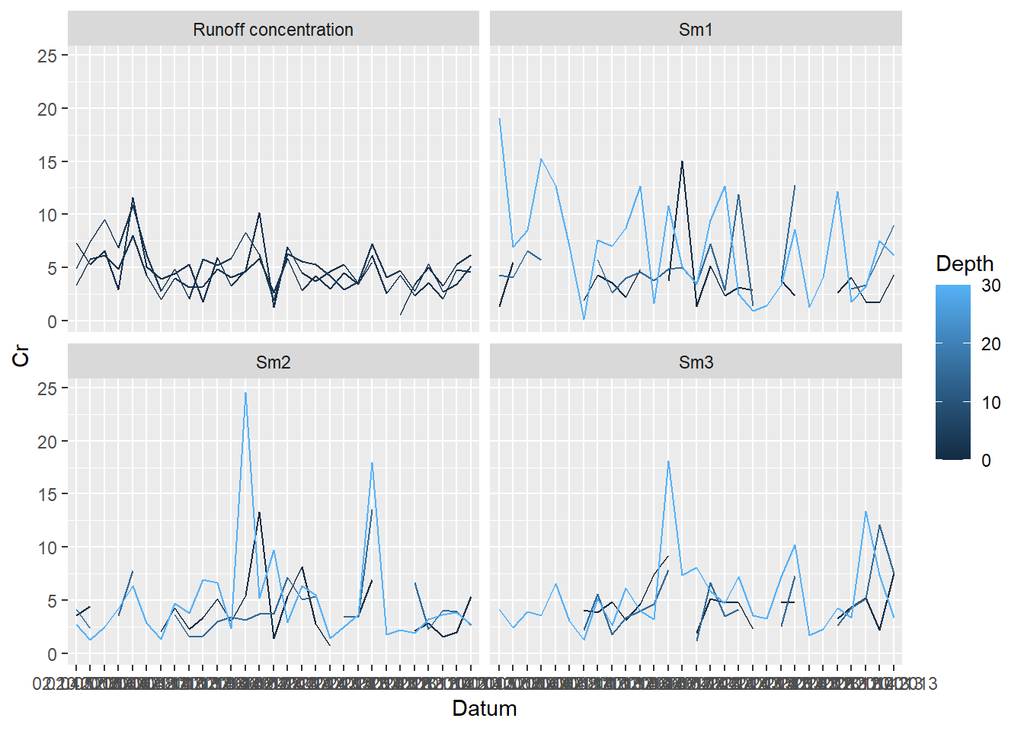

- Let R read the Datum column as datetime using as.Date.character() function: dd$Datum=as.Date.character(—-,“%d.%m.%Y”)

## now check the type of dd$Datum by typeof() function and test its class by class()

- Try to plot again the Datum vs Cr:

##ggplot(dd, aes( x = Datum, y = Cr, group = Depth, colors(Depth))) + geom_line(aes(color=Depth))+ facet_wrap(~Soil.material)

```r
typeof(dd$Datum)
```

```
## [1] "double"
```

```r
class(dd$Datum)
```

```
## [1] "Date"
```

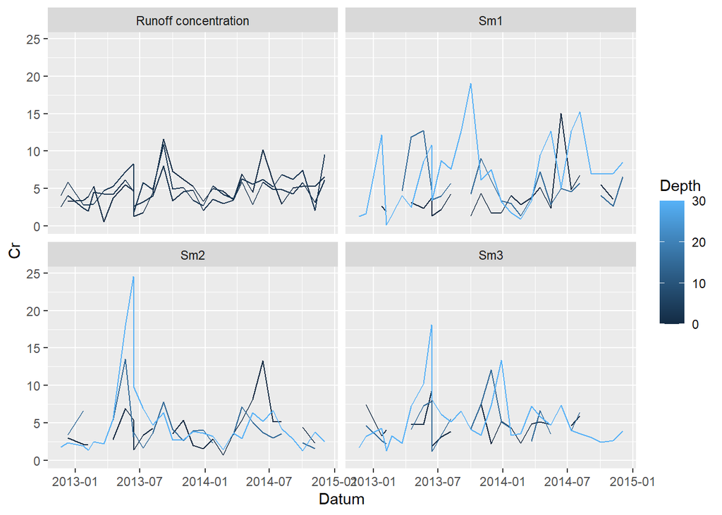

***

## we see above that they printed as date but stored as double, since they stored as numbers which indicate the number of days since 1970 the first day of 1970. if we check: using as.numeric()

- Use as.numeric() function to check the first 6 observations of Datum: head(as.numeric(–)
- Use > or < between the first two observations of Datum: Dd$Datum[1] -- dd$Datum[2]
- Add 1 to the frist observation of Datum: dd$Datum[1] + –

```r
head(as.numeric(dd$Datum))
```

```
## [1] 15665 15665 15665 15665 15665 15665
```

```r
dd$Datum[1] > dd$Datum[2]
```

```
## [1] FALSE
```

```r
dd$Datum[1] +1
```

```
## [1] "2012-11-22"
```

## next we learn something built in R functions that are useful for doing things related to dates and times

- Create dataframe called date_6 contains the first 6 obbs of Datum: — <- head(dd$Datum)
- Test these functions : weekdays(date_6) # tell you the weekday months(date_6) # tell you the month

Sys.Date () # tell you the current date date() # tell you the current date and time

```r
date_6 <- head(dd$Datum)
weekdays(date_6)   # tell you the weekday
```

```
## [1] "Mittwoch" "Mittwoch" "Mittwoch" "Mittwoch" "Mittwoch" "Mittwoch"
```

```r
months(date_6)     # tell you the month
```

```
## [1] "November" "November" "November" "November" "November" "November"
```

```r
Sys.Date ()        # tell you the current date
```

```
## [1] "2021-04-20"
```

```r
date()             # tell you the current date and time
```

```
## [1] "Tue Apr 20 09:21:06 2021"
```

- Use as.POSIXct to read Datum as date,called it date_ct: date_ct <- as.POSIXct(—) head(date_ct)

```r
date_ct <- as.POSIXct(dd$Datum)
head(date_ct)
```

```
## [1] "2012-11-21 01:00:00 CET" "2012-11-21 01:00:00 CET"
## [3] "2012-11-21 01:00:00 CET" "2012-11-21 01:00:00 CET"
## [5] "2012-11-21 01:00:00 CET" "2012-11-21 01:00:00 CET"
```

## Data from T1 project Role of dust and solid waste on water and contaminant transport processes at the pavement-water interface, Dr. Anne Timm

- Read the file “lys.txt“ called it lys, check its name columns, see the first 6 obbs and its datetime column structure: lys<- read.csv(— , sep =”;", header = T) names(–) head(–) str(—)

```r
lys<- read.csv("lys.txt", sep = ";", header = T)
names(lys)
```

```
##  [1] "datetime"                 "lys09_depth3_theta"
##  [3] "prec"                     "lys09_depth2_theta"
##  [5] "lys09_depth1_theta"       "lys09_depth3_temp"
##  [7] "lys09_depth2_temp"        "lys09_depth1_temp"
##  [9] "lys09_surface_temp"       "lys09_below_surface_temp"
## [11] "lys10_depth3_theta"       "lys10_depth2_theta"
## [13] "lys10_depth1_theta"       "lys10_depth1_theta_seam"
## [15] "lys10_depth1_theta_plate" "lys10_depth3_temp"
## [17] "lys10_depth2_temp"        "lys10_depth1_temp"
## [19] "lys10_depth1_temp_seam"   "lys10_depth1_temp_plate"
## [21] "lys10_surface_temp"       "lys10_below_surface_temp"
```

```r
head(lys)
```

```
##              datetime lys09_depth3_theta prec lys09_depth2_theta
## 1 2016-05-31 23:00:00              18.17  0.0              14.36
## 2 2016-06-01 00:00:00              18.13  0.0              14.35
## 3 2016-06-01 01:00:00              18.10  0.0              14.33
## 4 2016-06-01 02:00:00              18.05  0.0              14.28
## 5 2016-06-01 03:00:00              18.00  0.2              14.19
## 6 2016-06-01 04:00:00              17.96  1.8              14.07
##   lys09_depth1_theta lys09_depth3_temp lys09_depth2_temp lys09_depth1_temp
## 1              11.05             25.43             25.60             24.85
## 2              11.04             25.20             25.18             24.30
## 3              11.00             25.02             24.81             23.82
## 4              10.96             24.77             24.45             23.39
## 5              10.97             24.50             24.14             23.04
## 6              11.02             24.30             23.82             22.68
##   lys09_surface_temp lys09_below_surface_temp lys10_depth3_theta
```

[output cut: 34 more lines]

```r
str(lys$datetime)
```

```
##  chr [1:8271] "2016-05-31 23:00:00" "2016-06-01 00:00:00" ...
```

- Use as.POSIXlt() to read the datetime as date and time, called it d_dc, see its 6 obbs and its structure:

d_dc <- as.POSIXlt(–) head(–) str(–)

```r
d_dc <- as.POSIXlt(lys$datetime)
head(d_dc)
```

```
## [1] "2016-05-31 23:00:00 CEST" "2016-06-01 00:00:00 CEST"
## [3] "2016-06-01 01:00:00 CEST" "2016-06-01 02:00:00 CEST"
## [5] "2016-06-01 03:00:00 CEST" "2016-06-01 04:00:00 CEST"
```

```r
str(d_dc)
```

```
##  POSIXlt[1:8271], format: "2016-05-31 23:00:00" "2016-06-01 00:00:00" "2016-06-01 01:00:00" ...
```

# Subtract the time between d_dc[29] and d_dc[2]

- Subtract the time between d_dc[29] and d_dc[2]

```r
d_dc[29]- d_dc[2]
```

```
## Time difference of 1.125 days
```

## extract features of a date/time encoded as POSIKlt

$year # years $mon # numeric month $mday # day of the month $wday # day of the week $yday # day of the year $hour # hours $min # minutes $sec # seconds

- Extract day of the month for the first 6 obbs of d_dc: d_dc1<- head(–, 12) –$mday

```r
d_dc1<- head(d_dc)
d_dc1$mday
```

```
## [1] 31  1  1  1  1  1
```

```r
d_dc1 <- head(d_dc)
d_dc1$hour
```

```
## [1] 23  0  1  2  3  4
```

```r
head(d_dc1)
```

```
## [1] "2016-05-31 23:00:00 CEST" "2016-06-01 00:00:00 CEST"
## [3] "2016-06-01 01:00:00 CEST" "2016-06-01 02:00:00 CEST"
## [5] "2016-06-01 03:00:00 CEST" "2016-06-01 04:00:00 CEST"
```

# plotting the soil moisture of lysimter cobblestones vs datetime:

- try to plot the data of soil moisture between “2016-09-09 17:30:00” and “2017-03-01 02:30:00”:
- create dataframe d1 where:
- slect the datetime, lys09_depth1_theta from lys
- create new column called ly contians 8271 of “ly9”
- save it as file ‘theta091.csv’

d1 <- lys %>% select(datetime, lys09_depth1_theta) %>% mutate(ly=rep(‘ly9’, 8271)) %>% write_csv(‘theta091.csv’)

- rename the second column of d1 to “theta”

colnames(d1)[2]<- ‘theta’ head(d1) - check its 6 obbs by head()

- read the datetime of d1 as dates and times d1$datetime <- ymd_hms(d1$datetime)
- plot the whole data of theta vs datetime: ggplot(d1, aes(x =–, y =– )) + geom_line() weher x = datetime, y = theta
- plot the data of theta between “2016-09-09 17:30:00” and “2017-03-01 02:30:00” using as.POSIXct()

```r
d1 <- lys %>% select(datetime,lys09_depth1_theta) %>%
 mutate(ly=rep('ly9', 8271)) %>%
write_csv('theta091.csv')




colnames(d1)[2]<- 'theta'
head(d1)
```

```
##              datetime theta  ly
## 1 2016-05-31 23:00:00 11.05 ly9
## 2 2016-06-01 00:00:00 11.04 ly9
## 3 2016-06-01 01:00:00 11.00 ly9
## 4 2016-06-01 02:00:00 10.96 ly9
## 5 2016-06-01 03:00:00 10.97 ly9
## 6 2016-06-01 04:00:00 11.02 ly9
```

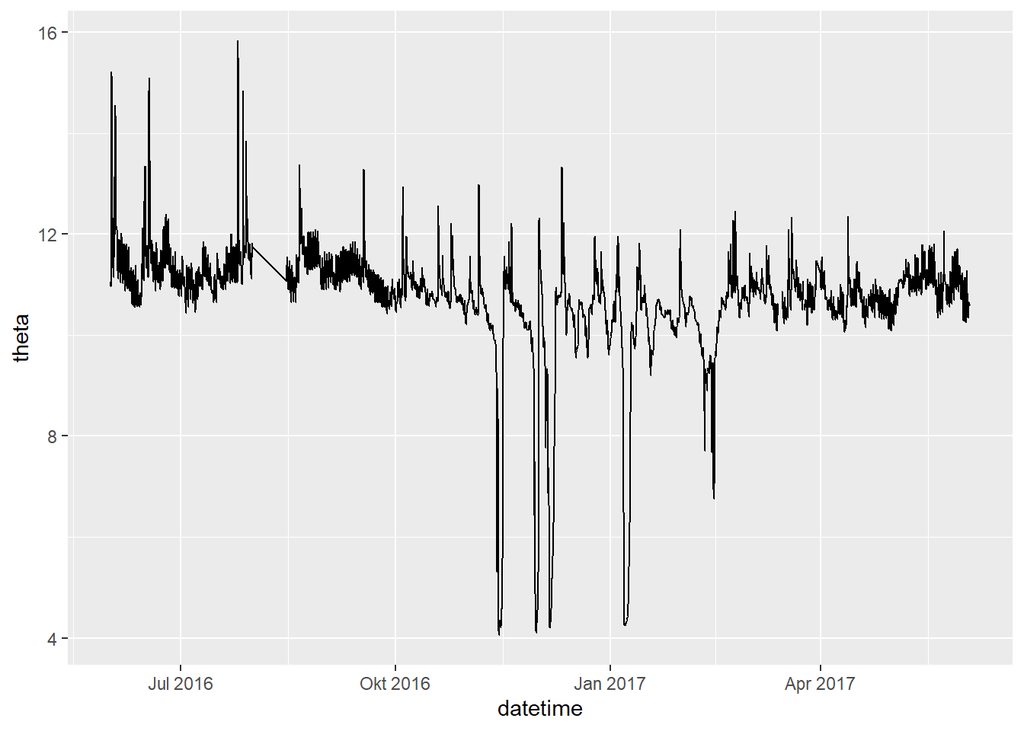

```r
d1$datetime <- ymd_hms(d1$datetime)

ggplot(d1, aes(x =datetime, y =theta )) + geom_line()
```

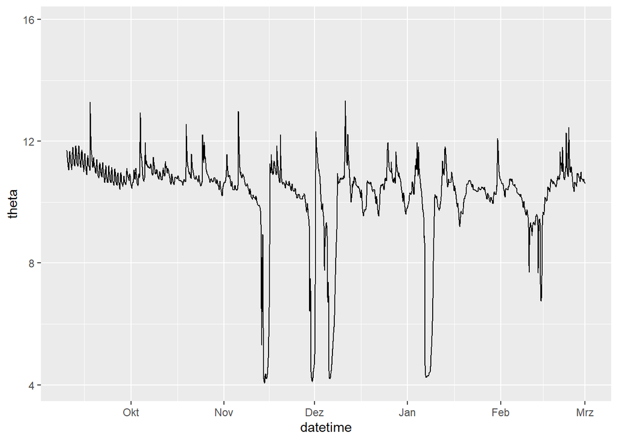

```r
ggplot(d1, aes(x =datetime, y =theta )) + geom_line() +
   xlim(as.POSIXct("2016-09-09 17:30:00"), as.POSIXct("2017-03-01 02:30:00"))
```

***

## to see the data of soil moisture vs datetime for each lysimter:

## ploting the soil moisture vs datetime for concrete slabs lysimter

- create dataframe d2 where:
- slect the datetime, lys10_depth1_theta from lys
- create new column called ly contians 8271 of “ly10”
- save it as file ‘theta101.csv’

d2 <- lys %>% select(datetime, lys10_depth1_theta) %>% mutate(ly=rep(‘ly10’, 8271)) %>% write_csv(‘theta101.csv’)

- rename the second column of d2 to “theta”

colnames(d2)[2]<- ‘theta’

- check its 6 obbs by head()
- read the datetime of d2 as dates and times d2$datetime <- ymd_hms(d2$datetime)
- create d3 that contains d1 and d2:

d3 <-rbind(d1,d2) - see the first 6 obbs: head(d3)

- plot the soil moisture (theta) from d3 vs datetime for each lysimter: ggplot(d3, aes(x =datetime , y = theta)) + geom_line() + facet_wrap(~ ly, ncol = 1)

```r
d2 <- lys %>%
  select(datetime, lys10_depth1_theta) %>%
  mutate(ly=rep('ly10', 8271)) %>%
  write_csv('theta101.csv')

colnames(d2)[2]<- 'theta'


d2$datetime <- ymd_hms(d2$datetime)


d3 <-rbind(d1,d2)
head(d3)
```

```
##              datetime theta  ly
## 1 2016-05-31 23:00:00 11.05 ly9
## 2 2016-06-01 00:00:00 11.04 ly9
## 3 2016-06-01 01:00:00 11.00 ly9
## 4 2016-06-01 02:00:00 10.96 ly9
## 5 2016-06-01 03:00:00 10.97 ly9
## 6 2016-06-01 04:00:00 11.02 ly9
```

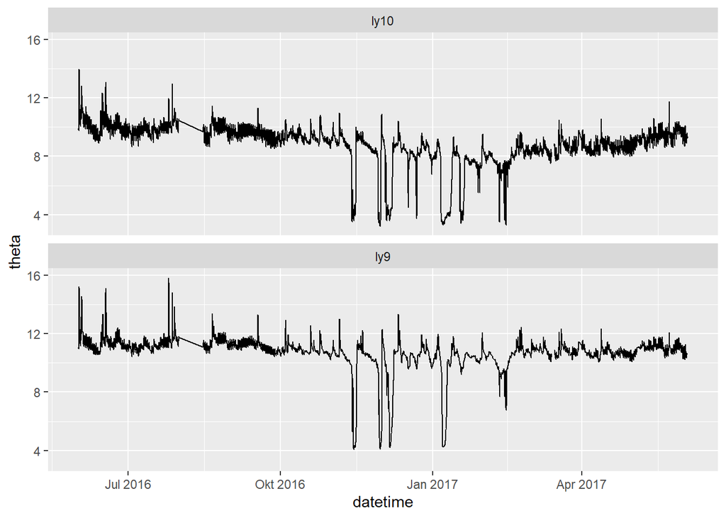

```r
#month<- month(d3$datetime,label =T)
#ggplot(d3, aes( x =theta, y= month, height= ..density.., fill= ly))+
   #   geom_density_ridges(alpha=0.25) + xlab('VWC_1')

#month1<- month(d1$datetime,label =T)
#names(d1)
ggplot(d3, aes(x =datetime , y = theta)) +
  geom_line() +
    facet_wrap(~ ly, ncol = 1)
```

```r
#ggplot(d1, aes(x =datetime, y =theta )) + geom_line() + scale_x_date(date_labels = "%m-%Y")
#summary(d1)
#j <-as.POSIXct("2016-09-09 17:30:00")
#str(j)
```

## Find the largest date

```r
last_date <- max(d1$datetime)
```

# data with the largest date

```r
last_data <- filter( d1, datetime == last_date)
```

```r
d3$ly <- as.factor(d3$ly)
release_time <- as.POSIXct("2016-09-10 18:00:00", tz = "UTC") # Universal Time Coordinated /

d3 %>%
   filter(d3$datetime > release_time, ly =="ly10" )
```

[output not shown]

## Parsing dates in lubridate

- Use ymd() from lubridate to read “2021-04-19”as date, called it t, check class(t) t <- ymd(–) class(t)
- Repeat it for "2021.04.19“, called it tt: tt <- ymd(–) class(tt) tt
- Try with "2021 Apr 19th“, called it ttt, check its class: ttt <- ymd(—-) class(ttt) ttt

```r
t <- ymd("2021-04-19")
class(t)
```

```
## [1] "Date"
```

```r
t
```

```
## [1] "2021-04-19"
```

```r
tt <- ymd("2021.04.19")
class(tt)
```

```
## [1] "Date"
```

```r
tt
```

```
## [1] "2021-04-19"
```

```r
ttt <- ymd("2021 Apr 19th")
class(ttt)
```

```
## [1] "Date"
```

```r
ttt
```

```
## [1] "2021-04-19"
```

```r
parse_date_time2("2021-04-19 13:30:06",  "YmdHMS", tz = "UTC", lt = TRUE) # could use  tz = "America/New_York"
```

```
## [1] "2021-04-19 13:30:06 UTC"
```

```r
parse_date_time("2021-04-19", orders="ymd")
```

```
## [1] "2021-04-19 UTC"
```

```r
parse_date_time(c("2021-04-19", "19-04-2021"),orders = c("ymd", "dmy"))
```

```
## [1] "2021-04-19 UTC" "2021-04-19 UTC"
```

```r
short_dates <- c("19 April 2021", "April 2021", "2021")
parse_date_time(short_dates, orders = c("dmY", "mY", "Y"))
```

```
## [1] "2021-04-19 UTC" "2021-04-01 UTC" "2021-01-01 UTC"
```

## Plot the Temperature below the surface pavement (concrete slabs) vs datetime

lys2 <- lys %>% mutate(datetime = ymd_hms(datetime)) #Create, modify, and delete columns head(lys2) g <- ggplot(lys2, aes(x = datetime, y = lys10_below_surface_temp)) + geom_line(color = “red”) g + labs(title = “Temperature below surface”, subtitle = “Concrete slabs”, caption = “Data source: Anne Timm, Thesis 2019”, x = “Date”, y = “Temperature C°”, tag = “A”) + theme( plot.title = element_text(hjust = 0.5), plot.subtitle = element_text(hjust = 0.5) )

```
##              datetime lys09_depth3_theta prec lys09_depth2_theta
## 1 2016-05-31 23:00:00              18.17  0.0              14.36
## 2 2016-06-01 00:00:00              18.13  0.0              14.35
## 3 2016-06-01 01:00:00              18.10  0.0              14.33
## 4 2016-06-01 02:00:00              18.05  0.0              14.28
## 5 2016-06-01 03:00:00              18.00  0.2              14.19
## 6 2016-06-01 04:00:00              17.96  1.8              14.07
##   lys09_depth1_theta lys09_depth3_temp lys09_depth2_temp lys09_depth1_temp
## 1              11.05             25.43             25.60             24.85
## 2              11.04             25.20             25.18             24.30
## 3              11.00             25.02             24.81             23.82
## 4              10.96             24.77             24.45             23.39
## 5              10.97             24.50             24.14             23.04
## 6              11.02             24.30             23.82             22.68
##   lys09_surface_temp lys09_below_surface_temp lys10_depth3_theta
```

[output cut: 34 more lines]

[output not shown]

[output cut: 34 more lines]

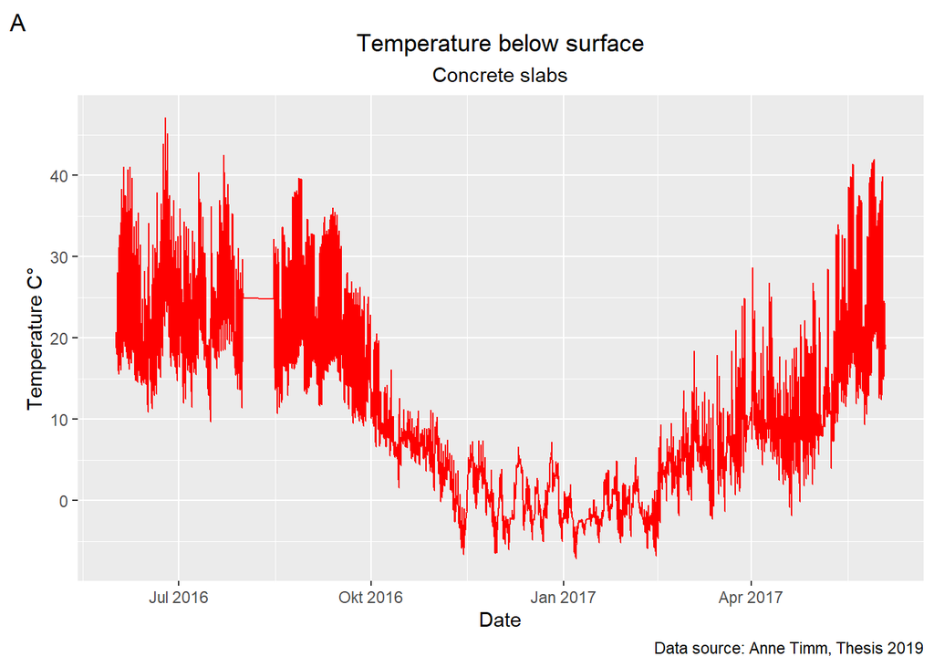

## make_date()function

- read the data from “datFlow.txt”, called it data, and check its first 6 obbs:

data<- read.csv(“—”, sep = ") head(—)

- create dataframe from data dataframe called data_hourly where datetime column contians Year, Month and day data ,using make_date() function:

data_hourly <- data %>% mutate(datetime = make_date(year = —, month = —-, day = —))

```r
data<- read.csv("datflow.txt", sep = "\t")
head(data)
```

```
##   Year Month day     time Discharge
## 1 2000     1   1 13:00:00  1244.419
## 2 2000     2   2 14:00:00  1720.690
## 3 2000     3   3 15:00:00  1533.871
## 4 2000     4   4 16:00:00  1239.000
## 5 2000     5   5 17:00:00  1579.677
## 6 2000     6   6 18:00:00  1589.000
```

```r
data_hourly  <- data  %>%
  mutate(datetime = make_date(year = Year, month = Month, day = day))
head(data_hourly)
```

```
##   Year Month day     time Discharge   datetime
## 1 2000     1   1 13:00:00  1244.419 2000-01-01
## 2 2000     2   2 14:00:00  1720.690 2000-02-02
## 3 2000     3   3 15:00:00  1533.871 2000-03-03
## 4 2000     4   4 16:00:00  1239.000 2000-04-04
## 5 2000     5   5 17:00:00  1579.677 2000-05-05
## 6 2000     6   6 18:00:00  1589.000 2000-06-06
```

```r
str(data_hourly)
```

```
## 'data.frame':    168 obs. of  6 variables:
##  $ Year     : int  2000 2000 2000 2000 2000 2000 2000 2000 2000 2000 ...
##  $ Month    : int  1 2 3 4 5 6 7 8 9 10 ...
##  $ day      : int  1 2 3 4 5 6 7 8 9 10 ...
##  $ time     : chr  "13:00:00" "14:00:00" "15:00:00" "16:00:00" ...
##  $ Discharge: num  1244 1721 1534 1239 1580 ...
##  $ datetime : Date, format: "2000-01-01" "2000-02-02" ...
```

```r
#View(data_hourly)
```

## plot Discharge, river ,m3/s vs datetime

- build dataframe from data_hourly called data_hourly2 ,add
  - column called datatime_string contians datetime and time columns with “T” letter as separation
  - column called datetime that read datatime_string as dates and times data_hourly2<- data_hourly %>% mutate( datetime_string = paste(datetime, time, sep = “T”), datetime = ymd_hms(datetime_string))
- see the first 6 obbs and its structure head(—) str(—)
- plot : g <- ggplot(data_hourly2, aes(x = datetime, y = Discharge)) + geom_line(color = “red”) g + labs(title = “Discharge, river ,m3/s”, subtitle = “Iran”, caption = “Data source: Fatima, Thesis 2017”, x = “Date”, y = “Discharge m3/s”, tag = “A”) + theme( plot.title = element_text(hjust = 0.5), plot.subtitle = element_text(hjust = 0.5) )

```r
 data_hourly2<- data_hourly  %>%
  mutate(
    datetime_string = paste(datetime, time, sep = "T"),
    datetime = ymd_hms(datetime_string))
 head(data_hourly2)
```

```
##   Year Month day     time Discharge            datetime     datetime_string
## 1 2000     1   1 13:00:00  1244.419 2000-01-01 13:00:00 2000-01-01T13:00:00
## 2 2000     2   2 14:00:00  1720.690 2000-02-02 14:00:00 2000-02-02T14:00:00
## 3 2000     3   3 15:00:00  1533.871 2000-03-03 15:00:00 2000-03-03T15:00:00
## 4 2000     4   4 16:00:00  1239.000 2000-04-04 16:00:00 2000-04-04T16:00:00
## 5 2000     5   5 17:00:00  1579.677 2000-05-05 17:00:00 2000-05-05T17:00:00
## 6 2000     6   6 18:00:00  1589.000 2000-06-06 18:00:00 2000-06-06T18:00:00
```

```r
  str(data_hourly2)
```

```
## 'data.frame':    168 obs. of  7 variables:
##  $ Year           : int  2000 2000 2000 2000 2000 2000 2000 2000 2000 2000 ...
##  $ Month          : int  1 2 3 4 5 6 7 8 9 10 ...
##  $ day            : int  1 2 3 4 5 6 7 8 9 10 ...
##  $ time           : chr  "13:00:00" "14:00:00" "15:00:00" "16:00:00" ...
##  $ Discharge      : num  1244 1721 1534 1239 1580 ...
##  $ datetime       : POSIXct, format: "2000-01-01 13:00:00" "2000-02-02 14:00:00" ...
##  $ datetime_string: chr  "2000-01-01T13:00:00" "2000-02-02T14:00:00" "2000-03-03T15:00:00" "2000-04-04T16:00:00" ...
```

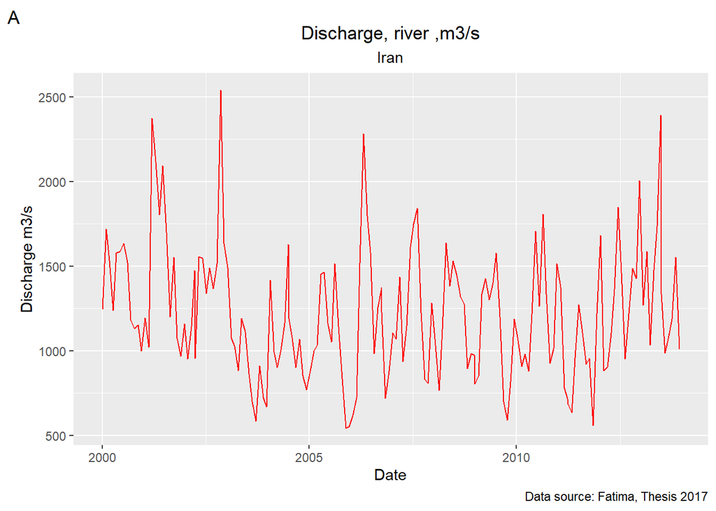

```r
  g <- ggplot(data_hourly2, aes(x = datetime, y = Discharge)) +
  geom_line(color = "red")
g + labs(title = "Discharge, river ,m3/s",
              subtitle = "Iran",
              caption = "Data source: Fatima, Thesis 2017",
              x = "Date", y = "Discharge m3/s",
              tag = "A") + theme(
  plot.title = element_text(hjust = 0.5),
  plot.subtitle = element_text(hjust = 0.5)
)
```

# Extracting parts of a datetime

```r
month(lys$datetime, label = T) %>% table()
```

```
## .
## Jan Feb Mrz Apr Mai Jun Jul Aug Sep Okt Nov Dez
## 744 672 615 720 666 791 738 399 720 742 720 744
```

```r
mean(hour(lys$datetime) < 13) #How often is the hour before 12 (noon)?
```

```
## [1] 0.5412888
```

```r
wday(lys$datetime, label =T) %>% table()
```

```
## .
##   So   Mo   Di   Mi   Do   Fr   Sa
## 1176 1165 1159 1193 1188 1187 1203
```

## MOre plot

```r
#lys$wday <- wday(lys$datetime, label =T)
#head(lys)
#head(d3)


d3$datetime <- ymd_hms(d3$datetime)

d3$ly <- as.factor(d3$ly)

summary(d3)
```

```
##     datetime                       theta           ly
##  Min.   :2016-05-31 23:00:00   Min.   : 3.200   ly10:8271
##  1st Qu.:2016-09-09 17:15:00   1st Qu.: 8.930   ly9 :8271
##  Median :2016-12-04 23:00:00   Median :10.100
##  Mean   :2016-12-03 14:13:46   Mean   : 9.746
##  3rd Qu.:2017-03-01 02:45:00   3rd Qu.:10.850
##  Max.   :2017-06-03 22:00:00   Max.   :15.830
##                                NA's   :25
```

```r
d3$month <- month(d3$datetime, label =T)

head(d3)
```

```
##              datetime theta  ly month
## 1 2016-05-31 23:00:00 11.05 ly9   Mai
## 2 2016-06-01 00:00:00 11.04 ly9   Jun
## 3 2016-06-01 01:00:00 11.00 ly9   Jun
## 4 2016-06-01 02:00:00 10.96 ly9   Jun
## 5 2016-06-01 03:00:00 10.97 ly9   Jun
## 6 2016-06-01 04:00:00 11.02 ly9   Jun
```

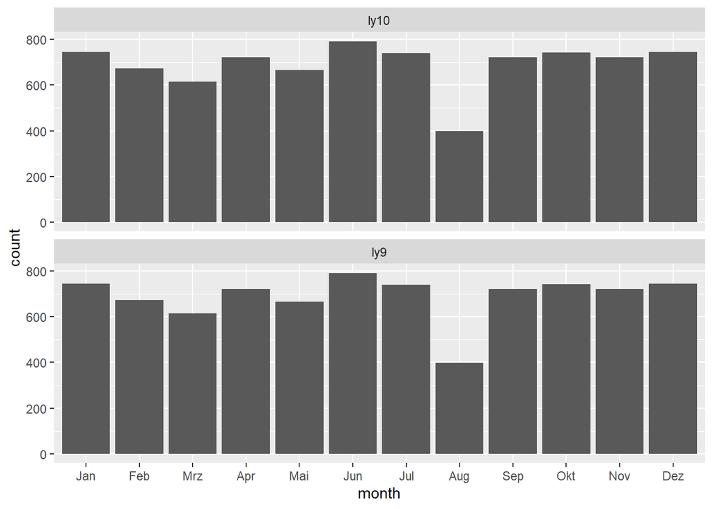

```r
ggplot(d3, aes(month)) +
  geom_bar() +
  facet_wrap(~ ly, ncol = 1, scale = "free_y")
```

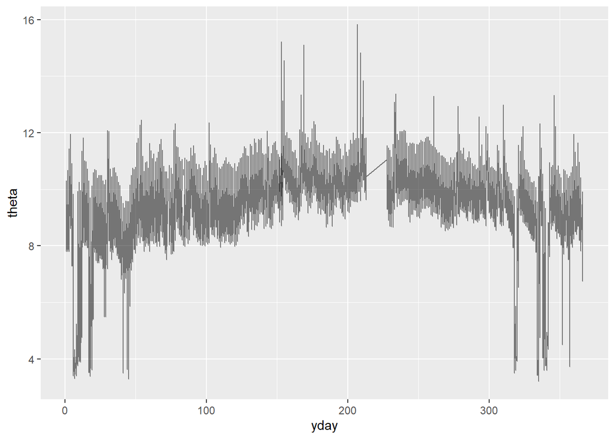

```r
d3_daily <- d3 %>%
  mutate(
    year = year(datetime),
    yday = yday(datetime),
    month = month(datetime, label = TRUE))

# plot theta for for all years
ggplot(d3_daily, aes(x = yday, y = theta)) +
  geom_line(aes(group = year), alpha = 0.5)
```

# distribution of soil moisture below the lysimter (ly10 = concrete slabs , ly9= cobbelstones) by month

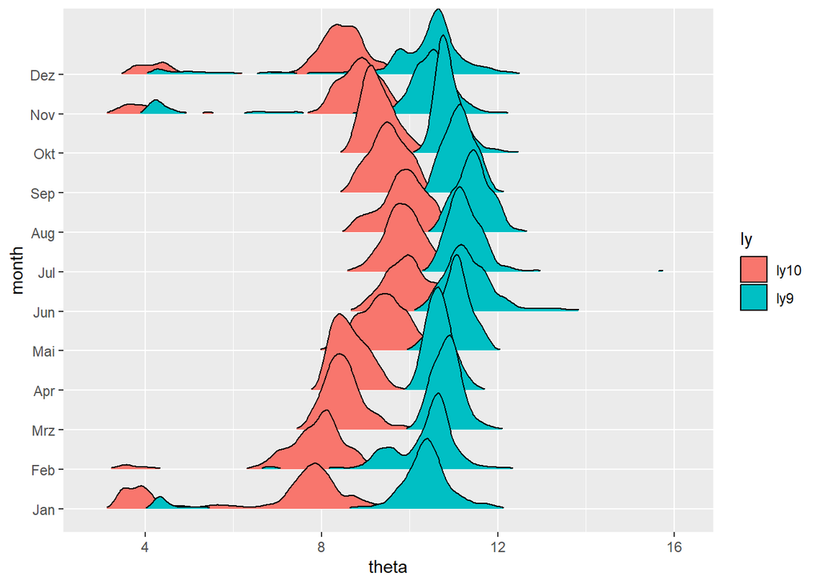

```r
month<- month(d3$datetime,label =T)

ggplot(d3, aes(x = theta, y = month, height = ..density.., fill=ly))  +
geom_density_ridges(scale = 3, rel_min_height = 0.01)
```

# from Data Anne Timm, Climate data, How many rain events for each month

```r
clim <- read.csv("climate_hour_all.txt", sep=";")
#head(clim)
clim$datetime<- ymd_hms(clim$datetime)


pre_hourly <- clim %>%   # create new columnes
  mutate(
    hour = hour(datetime),
    year = year(datetime),
    month = month(datetime, label = TRUE),
    rainy = prec > 0
  )
#View(pre_hourly)

pre_day <- pre_hourly %>%    # Filter for hours between 8am and 10pm (inclusive)
  filter(hour >= 8, hour <= 22)

#head(pre_day)

rainy_days <- pre_day %>%    # Summarise for each date if there is any rain
  group_by(month, datetime) %>%
  summarise(
    any_rain = any(rainy)
  )
#View(rainy_days)

rainy_days %>%  # Summarise for each month, the number of days with rain
  summarise(
    days_rainy = sum(any_rain)
  )
```

```
## # A tibble: 12 x 2
##    month days_rainy
##    <ord>      <int>
##  1 Jan           77
##  2 Feb           72
##  3 Mrz           52
##  4 Apr           42
##  5 Mai           29
##  6 Jun           25
##  7 Jul           36
##  8 Aug           25
##  9 Sep            7
## 10 Okt           81
## 11 Nov           59
## 12 Dez           54
```

```r
clim_time<- clim$datetime
head(clim_time)
```

```
## [1] "2016-06-03 00:00:00 UTC" "2016-06-03 01:00:00 UTC"
## [3] "2016-06-03 02:00:00 UTC" "2016-06-03 03:00:00 UTC"
## [5] "2016-06-03 04:00:00 UTC" "2016-06-03 05:00:00 UTC"
```

```r
head(clim_time) %>%  hour()
```

```
## [1] 0 1 2 3 4 5
```

```r
head(clim_time) %>% ceiling_date(unit = "hour")
```

```
## [1] "2016-06-03 00:00:00 UTC" "2016-06-03 01:00:00 UTC"
## [3] "2016-06-03 02:00:00 UTC" "2016-06-03 03:00:00 UTC"
## [5] "2016-06-03 04:00:00 UTC" "2016-06-03 05:00:00 UTC"
```

```r
clim_hourly <- clim%>%
  mutate(
    day = floor_date(datetime, unit = "day")
  )
head(clim_hourly)
```

```
##              datetime tair prec   rh  rs u10   pair tdew        day
## 1 2016-06-03 00:00:00 17.1  5.0 91.9   1 1.7 1003.6 15.9 2016-06-03
## 2 2016-06-03 01:00:00 16.6  1.9 95.0   1 0.8 1003.8 15.9 2016-06-03
## 3 2016-06-03 02:00:00 16.9  0.0 95.4   1 1.3 1003.8 16.2 2016-06-03
## 4 2016-06-03 03:00:00 16.4  0.0 95.3   1 1.2 1003.8 15.7 2016-06-03
## 5 2016-06-03 04:00:00 16.1  0.0 96.6  36 1.2 1003.8 15.6 2016-06-03
## 6 2016-06-03 05:00:00 17.5  0.0 92.5 159 1.4 1003.8 16.4 2016-06-03
```

```r
head(clim_time) %>% floor_date(unit = "hour")
```

```
## [1] "2016-06-03 00:00:00 UTC" "2016-06-03 01:00:00 UTC"
## [3] "2016-06-03 02:00:00 UTC" "2016-06-03 03:00:00 UTC"
## [5] "2016-06-03 04:00:00 UTC" "2016-06-03 05:00:00 UTC"
```

```r
clim_hourly <- clim%>%
  mutate(
    day = floor_date(datetime, unit = "day")
  )
```

```r
clim_hourly %>%   # Count observations per day
  count(day)
```

```
##            day  n
## 1   2016-06-03 24
## 2   2016-06-04 24
## 3   2016-06-05 24
## 4   2016-06-06 24
## 5   2016-06-07 24
## 6   2016-06-08 24
## 7   2016-06-09 24
## 8   2016-06-10 24
## 9   2016-06-11 24
## 10  2016-06-12 24
## 11  2016-06-13 24
## 12  2016-06-14 24
## 13  2016-06-15 24
## 14  2016-06-16 24
```

[output cut: 351 more lines]

```r
data(climatedata)

head(climatedata)
```

```
##   Station.Number Year Month Day Hour Temp Tdew RH   n       uz
## 1          23090 2001     3   1    0 16.7 10.7 68 8.6 2.611111
## 2          23090 2001     3   1    3 16.8  8.8 59 8.6 2.111111
## 3          23090 2001     3   1    6 15.1  9.0 67 8.6 2.611111
## 4          23090 2001     3   1    9 19.4 10.1 55 8.6 1.000000
## 5          23090 2001     3   1   12 26.7  8.9 33 8.6 0.000000
## 6          23090 2001     3   1   15 28.8  9.4 30 8.6 2.111111
```

```r
dat <- climatedata %>%
  mutate(datetime=make_date( year=Year, month=Month, day=Day))
head(dat)
```

```
##   Station.Number Year Month Day Hour Temp Tdew RH   n       uz   datetime
## 1          23090 2001     3   1    0 16.7 10.7 68 8.6 2.611111 2001-03-01
## 2          23090 2001     3   1    3 16.8  8.8 59 8.6 2.111111 2001-03-01
## 3          23090 2001     3   1    6 15.1  9.0 67 8.6 2.611111 2001-03-01
## 4          23090 2001     3   1    9 19.4 10.1 55 8.6 1.000000 2001-03-01
## 5          23090 2001     3   1   12 26.7  8.9 33 8.6 0.000000 2001-03-01
## 6          23090 2001     3   1   15 28.8  9.4 30 8.6 2.111111 2001-03-01
```